# automatization_notebook

2024-10-13

# Чтение данных

В вашем варианте нужно использовать датасеты cardio_train_big или cardio_train_not_too_big.

```r
mydf <- read_csv2("data/raw/cardio_train_big.csv")
```

```
## ℹ Using "','" as decimal and "'.'" as grouping mark. Use `read_delim()` for more control.
```

# Выведите общее описание данных

```r
mydf %>%
  glimpse()
```

```
## Rows: 70,000
## Columns: 13
## $ id          <dbl> 0, 1, 2, 3, 4, 8, 9, 12, 13, 14, 15, 16, 18, 21, 23, 24, 2…
## $ age         <dbl> 18393, 20228, 18857, 17623, 17474, 21914, 22113, 22584, 17…
## $ gender      <dbl> 2, 1, 1, 2, 1, 1, 1, 2, 1, 1, 1, 2, 2, 1, 2, 2, 1, 1, 1, 2…
## $ height      <dbl> 168, 156, 165, 169, 156, 151, 157, 178, 158, 164, 169, 173…
## $ weight      <dbl> 620, 850, 640, 820, 560, 670, 930, 950, 710, 680, 800, 600…
## $ ap_hi       <dbl> 110, 140, 130, 150, 100, 120, 130, 130, 110, 110, 120, 120…
## $ ap_lo       <dbl> 80, 90, 70, 100, 60, 80, 80, 90, 70, 60, 80, 80, 80, 70, 9…
## $ cholesterol <dbl> 1, 3, 3, 1, 1, 2, 3, 3, 1, 1, 1, 1, 1, 1, 1, 1, 1, 1, 1, 1…
## $ gluc        <dbl> 1, 1, 1, 1, 1, 2, 1, 3, 1, 1, 1, 1, 1, 1, 1, 1, 1, 3, 1, 1…
## $ smoke       <dbl> 0, 0, 0, 0, 0, 0, 0, 0, 0, 0, 0, 0, 0, 0, 1, 0, 0, 0, 0, 1…
## $ alco        <dbl> 0, 0, 0, 0, 0, 0, 0, 0, 0, 0, 0, 0, 0, 0, 1, 0, 0, 0, 0, 0…
## $ active      <dbl> 1, 1, 0, 1, 0, 0, 1, 1, 1, 0, 1, 1, 0, 1, 1, 0, 0, 1, 0, 1…
## $ cardio      <dbl> 0, 1, 1, 1, 0, 0, 0, 1, 0, 0, 0, 0, 0, 0, 0, 1, 0, 0, 0, 0…
```

```r
summary(mydf)
```

```
##        id             age            gender         height
##  Min.   :    0   Min.   :10798   Min.   :1.00   Min.   : 55.0
##  1st Qu.:25007   1st Qu.:17664   1st Qu.:1.00   1st Qu.:159.0
##  Median :50002   Median :19703   Median :1.00   Median :165.0
##  Mean   :49972   Mean   :19469   Mean   :1.35   Mean   :164.4
##  3rd Qu.:74889   3rd Qu.:21327   3rd Qu.:2.00   3rd Qu.:170.0
##  Max.   :99999   Max.   :23713   Max.   :2.00   Max.   :250.0
##      weight           ap_hi             ap_lo           cholesterol
##  Min.   : 100.0   Min.   : -150.0   Min.   :  -70.00   Min.   :1.000
##  1st Qu.: 650.0   1st Qu.:  120.0   1st Qu.:   80.00   1st Qu.:1.000
##  Median : 720.0   Median :  120.0   Median :   80.00   Median :1.000
##  Mean   : 742.5   Mean   :  128.8   Mean   :   96.63   Mean   :1.367
##  3rd Qu.: 820.0   3rd Qu.:  140.0   3rd Qu.:   90.00   3rd Qu.:2.000
##  Max.   :7994.0   Max.   :16020.0   Max.   :11000.00   Max.   :3.000
##       gluc           smoke              alco             active
##  Min.   :1.000   Min.   :0.00000   Min.   :0.00000   Min.   :0.0000
##  1st Qu.:1.000   1st Qu.:0.00000   1st Qu.:0.00000   1st Qu.:1.0000
##  Median :1.000   Median :0.00000   Median :0.00000   Median :1.0000
##  Mean   :1.226   Mean   :0.08813   Mean   :0.05377   Mean   :0.8037
##  3rd Qu.:1.000   3rd Qu.:0.00000   3rd Qu.:0.00000   3rd Qu.:1.0000
##  Max.   :3.000   Max.   :1.00000   Max.   :1.00000   Max.   :1.0000
##      cardio
##  Min.   :0.0000
##  1st Qu.:0.0000
##  Median :0.0000
##  Mean   :0.4997
##  3rd Qu.:1.0000
##  Max.   :1.0000
```

Вывод: Возраст нормально представлен Пол - сделать фактором и переименовать Рост - убрать аутлаеры Вес - с ним что-то не то, впечатление что надо разделить на 10 и убрать аутлаеры Давление - убрать отрицательные значения и аутлаеры Остальные переменные - сделать фактором и переименовать

Стратегия чистки данных такая: нереалистичные данные заменяем на NA, потом убираем строки и столбцы где много NA, потом убираем строки с аутлаерами. Если осталось хотя бы 50 тысяч строк из 70 тысяч - все окей.

```r
# Преобразование возраста в года и округление до целого
df <- mydf %>%
  mutate(
    age = as.integer(age / 365),  # Делим возраст на 365 и преобразуем в целое число
    weight = as.numeric(weight/ 10),  # Преобразуем вес в целое число и тоже делим на 10
    ap_hi = as.numeric(ap_hi),    # Преобразуем systolic BP в целое число
    ap_lo = as.numeric(ap_lo)     # Преобразуем diastolic BP в целое число
  )
# Замена значений в факторных переменных
df <- df %>%
  mutate(
    gender = as.factor(recode(gender, `1` = 'Ж', `2` = 'М')),
    gluc = as.factor(recode(gluc, `1` = 'норма', `2` = 'повышенный', `3` = 'высокий')),
    cholesterol = as.factor(recode(cholesterol, `1` = 'норма', `2` = 'повышенный', `3` = 'высокий')),
    smoke = as.factor(recode(smoke, `0` = 'некурящий', `1` = 'курящий')),
    alco = as.factor(recode(alco, `0` = 'не употребляет', `1` = 'употребляет')),
    active = as.factor(recode(active, `0` = 'не активен', `1` = 'активен')),
    cardio = as.factor(recode(cardio, `0` = 'не болен', `1` = 'болен'))
  )
# Выводим статистику
summary(df)
```

```
##        id             age        gender        height          weight
##  Min.   :    0   Min.   :29.00   Ж:45530   Min.   : 55.0   Min.   : 10.00
##  1st Qu.:25007   1st Qu.:48.00   М:24470   1st Qu.:159.0   1st Qu.: 65.00
##  Median :50002   Median :53.00             Median :165.0   Median : 72.00
##  Mean   :49972   Mean   :52.84             Mean   :164.4   Mean   : 74.25
##  3rd Qu.:74889   3rd Qu.:58.00             3rd Qu.:170.0   3rd Qu.: 82.00
##  Max.   :99999   Max.   :64.00             Max.   :250.0   Max.   :799.40
##      ap_hi             ap_lo              cholesterol            gluc
##  Min.   : -150.0   Min.   :  -70.00   высокий   : 8066   высокий   : 5331
##  1st Qu.:  120.0   1st Qu.:   80.00   норма     :52385   норма     :59479
##  Median :  120.0   Median :   80.00   повышенный: 9549   повышенный: 5190
##  Mean   :  128.8   Mean   :   96.63
##  3rd Qu.:  140.0   3rd Qu.:   90.00
##  Max.   :16020.0   Max.   :11000.00
##        smoke                   alco              active           cardio
##  курящий  : 6169   не употребляет:66236   активен   :56261   болен   :34979
##  некурящий:63831   употребляет   : 3764   не активен:13739   не болен:35021
##
##
##
##
```

Заменяем на NA совсем нереалистичные значения

```r
df <- df %>%
  mutate(
    # Заменяем ap_hi и ap_lo на NA, если ap_hi меньше ap_lo
    ap_hi = ifelse(ap_hi < ap_lo, NA, ap_hi),
    ap_lo = ifelse(ap_hi < ap_lo, NA, ap_lo),
    height = ifelse(height < 100, NA, height),  # Заменяем height на NA, если меньше 100
    height = ifelse(height > 250, NA, height),  # Заменяем height на NA, если больше 250
    weight = ifelse(weight < 25, NA, weight),   # Заменяем weight на NA, если меньше 25
    weight = ifelse(weight > 500, NA, weight),   # Заменяем weight на NA, если больше 500
    ap_hi = ifelse(ap_hi < 30, NA, ap_hi),      # Заменяем ap_hi на NA, если меньше 30
    ap_hi = ifelse(ap_hi > 300, NA, ap_hi),      # Заменяем ap_hi на NA, если больше 300
    ap_lo = ifelse(ap_lo < 30, NA, ap_lo),      # Заменяем ap_lo на NA, если меньше 30
    ap_lo = ifelse(ap_lo > 300, NA, ap_lo)      # Заменяем ap_lo на NA, если больше 300
    )
summary(df)
```

```
##        id             age        gender        height          weight
##  Min.   :    0   Min.   :29.00   Ж:45530   Min.   :100.0   Min.   : 28.00
##  1st Qu.:25007   1st Qu.:48.00   М:24470   1st Qu.:159.0   1st Qu.: 65.00
##  Median :50002   Median :53.00             Median :165.0   Median : 72.00
##  Mean   :49972   Mean   :52.84             Mean   :164.4   Mean   : 74.21
##  3rd Qu.:74889   3rd Qu.:58.00             3rd Qu.:170.0   3rd Qu.: 82.00
##  Max.   :99999   Max.   :64.00             Max.   :250.0   Max.   :354.50
##                                            NA's   :29      NA's   :10
##      ap_hi           ap_lo           cholesterol            gluc
##  Min.   : 60.0   Min.   : 30.0   высокий   : 8066   высокий   : 5331
##  1st Qu.:120.0   1st Qu.: 80.0   норма     :52385   норма     :59479
##  Median :120.0   Median : 80.0   повышенный: 9549   повышенный: 5190
##  Mean   :126.7   Mean   : 81.3
##  3rd Qu.:140.0   3rd Qu.: 90.0
##  Max.   :240.0   Max.   :182.0
##  NA's   :1279    NA's   :1287
##        smoke                   alco              active           cardio
##  курящий  : 6169   не употребляет:66236   активен   :56261   болен   :34979
##  некурящий:63831   употребляет   : 3764   не активен:13739   не болен:35021
##
##
##
##
##
```

# Очистка данных

Уберите переменные, в которых пропущенных значений больше 20% или уберите субъектов со слишком большим количеством пропущенных значений. Или совместите оба варианта. Напишите обоснование, почему вы выбрали тот или иной вариант:

**Обоснование**: В переменных давления по 1300 NA´s, что вполне допустимо для датасета в 70 тысяч значений, поэтому я не удаляла переменные. Нашлось три субъекта с 20% пропущенных, удалила их.

Ищем субъектов с 20% пропущенных значений

```r
num_rows_with_na <- df %>%
  filter(rowSums(is.na(.)) >= 3) %>%  # Считаем количество NA в каждой строке и фильтруем строки с тремя и больше NA (20% от 12 переменных)
  nrow()  # Подсчет количества таких строк

num_rows_with_na
```

```
## [1] 3
```

Три человека - это ок, можем пожертвовать ими

```r
# Удаление строк с тремя или более NA
df <- df %>%
  filter(rowSums(is.na(.)) < 3)
summary(df)
```

```
##        id             age        gender        height          weight
##  Min.   :    0   Min.   :29.00   Ж:45528   Min.   :100.0   Min.   : 28.00
##  1st Qu.:25007   1st Qu.:48.00   М:24469   1st Qu.:159.0   1st Qu.: 65.00
##  Median :50001   Median :53.00             Median :165.0   Median : 72.00
##  Mean   :49972   Mean   :52.84             Mean   :164.4   Mean   : 74.22
##  3rd Qu.:74886   3rd Qu.:58.00             3rd Qu.:170.0   3rd Qu.: 82.00
##  Max.   :99999   Max.   :64.00             Max.   :250.0   Max.   :354.50
##                                            NA's   :27      NA's   :9
##      ap_hi           ap_lo           cholesterol            gluc
##  Min.   : 60.0   Min.   : 30.0   высокий   : 8066   высокий   : 5331
##  1st Qu.:120.0   1st Qu.: 80.0   норма     :52383   норма     :59477
##  Median :120.0   Median : 80.0   повышенный: 9548   повышенный: 5189
##  Mean   :126.7   Mean   : 81.3
##  3rd Qu.:140.0   3rd Qu.: 90.0
##  Max.   :240.0   Max.   :182.0
##  NA's   :1276    NA's   :1284
##        smoke                   alco              active           cardio
##  курящий  : 6169   не употребляет:66233   активен   :56259   болен   :34977
##  некурящий:63828   употребляет   : 3764   не активен:13738   не болен:35020
##
##
##
##
##
```

```r
# Отсортируйте данные по возрасту по убыванию
df <- df %>%
   arrange(desc(age))
```

Дальше я разбиваю данные на две группы: кардио и не-кардио, и буду рассматривать значения на предмет поиска выбивающихся значений отдельно в каждой группе

```r
# Определение аутлаеров
outliers <- df %>%
  group_by(cardio) %>%
  # Для каждой группы находим среднее и стандартное отклонение
  summarise(
    height_mean = mean(height, na.rm = TRUE),
    height_sd = sd(height, na.rm = TRUE),
    weight_mean = mean(weight, na.rm = TRUE),
    weight_sd = sd(weight, na.rm = TRUE),
    ap_hi_mean = mean(ap_hi, na.rm = TRUE),
    ap_hi_sd = sd(ap_hi, na.rm = TRUE),
    ap_lo_mean = mean(ap_lo, na.rm = TRUE),
    ap_lo_sd = sd(ap_lo, na.rm = TRUE),
    .groups = 'drop'
  ) %>%
  # Соединяем результаты по группе для каждого субъекта
  inner_join(df, by = "cardio") %>%
  # Определяем аутлаеры
  filter(
    (height < (height_mean - 3 * height_sd) | height > (height_mean + 3 * height_sd)) |
    (weight < (weight_mean - 3 * weight_sd) | weight > (weight_mean + 3 * weight_sd)) |
    (ap_hi < (ap_hi_mean - 3 * ap_hi_sd) | ap_hi > (ap_hi_mean + 3 * ap_hi_sd)) |
    (ap_lo < (ap_lo_mean - 3 * ap_lo_sd) | ap_lo > (ap_lo_mean + 3 * ap_lo_sd))
  )
write.csv(outliers, "outliers.csv")
```

```r
# Удаляем аутлаеры из исходного датасета
cleaned_data <- df %>%
  anti_join(outliers)
```

[output not shown]

```r
summary(cleaned_data)
```

```
##        id             age        gender        height          weight
##  Min.   :    0   Min.   :29.00   Ж:44291   Min.   :141.0   Min.   : 32.00
##  1st Qu.:25007   1st Qu.:48.00   М:23629   1st Qu.:159.0   1st Qu.: 65.00
##  Median :50011   Median :53.00             Median :165.0   Median : 72.00
##  Mean   :49980   Mean   :52.83             Mean   :164.4   Mean   : 73.58
##  3rd Qu.:74889   3rd Qu.:58.00             3rd Qu.:170.0   3rd Qu.: 81.00
##  Max.   :99999   Max.   :64.00             Max.   :188.0   Max.   :121.30
##                                            NA's   :23      NA's   :8
##      ap_hi           ap_lo            cholesterol            gluc
##  Min.   : 85.0   Min.   : 54.00   высокий   : 7699   высокий   : 5093
##  1st Qu.:120.0   1st Qu.: 80.00   норма     :51100   норма     :57931
##  Median :120.0   Median : 80.00   повышенный: 9121   повышенный: 4896
##  Mean   :125.9   Mean   : 81.02
##  3rd Qu.:140.0   3rd Qu.: 90.00
##  Max.   :185.0   Max.   :113.00
##  NA's   :1248    NA's   :1253
##        smoke                   alco              active           cardio
##  курящий  : 5931   не употребляет:64323   активен   :54618   болен   :34089
##  некурящий:61989   употребляет   : 3597   не активен:13302   не болен:33831
##
##
##
##
##
```

Теперь все данные более-менее хорошо выглядят, нет выбивающихся значений, все красиво

Задание было:

2. Переименуйте переменные в человекочитаемый вид (что делать с пробелами в названиях?);
3. В соответствии с описанием данных приведите переменные к нужному типу (numeric или factor);
4. Отсортируйте данные по возрасту по убыванию;
5. Сохраните в файл outliers.csv субъектов, которые являются выбросами (например, по правилу трёх сигм) — это необязательное задание со звёздочкой;
6. Присвойте получившийся датасет переменной “cleaned_data”.

# Сколько осталось переменных?

```r
ncol(cleaned_data)
```

```
## [1] 13
```

Осталось 12 переменных (первый столбик - id)

# Сколько осталось случаев?

```r
nrow(cleaned_data)
```

```
## [1] 67920
```

Осталось 67920 случаев

# Есть ли в данных идентичные строки?

```r
sum(duplicated(cleaned_data) | duplicated(cleaned_data))
```

```
## [1] 0
```

Нет, идентичных строк нет

# Сколько всего переменных с пропущенными значениями в данных и сколько пропущенных точек в каждой такой переменной?

```r
na_counts <- cleaned_data %>%
  summarise(
    height_na = sum(is.na(height)),
    weight_na = sum(is.na(weight)),
    ap_hi_na = sum(is.na(ap_hi)),
    ap_lo_na = sum(is.na(ap_lo))
  )
na_counts
```

| height_na | weight_na | ap_hi_na | ap_lo_na |
| --- | --- | --- | --- |
| 23 | 8 | 1248 | 1253 |

Всего четыре переменные с пропущенными значениями: height, weight, ap_hi, ap_lo, height_na - 23 weight_na - 8 ap_hi_na - 1248 ap_lo_na - 1253

# Добавляем ИМТ

Исходя из базовых знаний, мы знаем, что и в этом датасете скорее всего вероятность наличия сердечно-сосудистых заболеваний связана с весом человека, но не с ростом, хотя вес человека сильно зависит от роста. И мы знаем, что есть такой параметр как ИМТ, который позволяет выявить наличие избыточного веса. Добавим параметр BMI в таблицу.

```r
cleaned_data$BMI <- round(cleaned_data$weight / ((cleaned_data$height / 100)^2), 2)
summary(cleaned_data)
```

```
##        id             age        gender        height          weight
##  Min.   :    0   Min.   :29.00   Ж:44291   Min.   :141.0   Min.   : 32.00
##  1st Qu.:25007   1st Qu.:48.00   М:23629   1st Qu.:159.0   1st Qu.: 65.00
##  Median :50011   Median :53.00             Median :165.0   Median : 72.00
##  Mean   :49980   Mean   :52.83             Mean   :164.4   Mean   : 73.58
##  3rd Qu.:74889   3rd Qu.:58.00             3rd Qu.:170.0   3rd Qu.: 81.00
##  Max.   :99999   Max.   :64.00             Max.   :188.0   Max.   :121.30
##                                            NA's   :23      NA's   :8
##      ap_hi           ap_lo            cholesterol            gluc
##  Min.   : 85.0   Min.   : 54.00   высокий   : 7699   высокий   : 5093
##  1st Qu.:120.0   1st Qu.: 80.00   норма     :51100   норма     :57931
##  Median :120.0   Median : 80.00   повышенный: 9121   повышенный: 4896
##  Mean   :125.9   Mean   : 81.02
##  3rd Qu.:140.0   3rd Qu.: 90.00
##  Max.   :185.0   Max.   :113.00
##  NA's   :1248    NA's   :1253
##        smoke                   alco              active           cardio
##  курящий  : 5931   не употребляет:64323   активен   :54618   болен   :34089
##  некурящий:61989   употребляет   : 3597   не активен:13302   не болен:33831
##
##
##
##
##
##       BMI
##  Min.   :12.25
##  1st Qu.:23.88
##  Median :26.26
##  Mean   :27.26
##  3rd Qu.:30.06
##  Max.   :55.46
##  NA's   :31
```

# Описательные статистики

```r
statistics <- list(
      `Количество субъектов` = ~length(.x) %>% as.character(),
      `Количество (есть данные)` = ~sum(!is.na(.x)) %>% as.character(),
      `Нет данных` = ~sum(is.na(.x)) %>% as.character(),
      `Ср. знач.` = ~ifelse(sum(!is.na(.x)) == 0, "Н/П*", mean(.x, na.rm = TRUE) %>% round(2) %>% as.character()),
      `Станд. отклон.` = ~ifelse(sum(!is.na(.x)) < 3, "Н/П*", sd(.x, na.rm = TRUE) %>% round(2) %>% as.character()),
      `95% ДИ для среднего` = ~ifelse(sum(!is.na(.x)) < 3, "Н/П*", paste0(ci_min(.x) %>% round(2), " - ", ci_max(.x) %>% round(2))),
      `мин. - макс.` = ~ifelse(sum(!is.na(.x)) == 0, "Н/П*", paste0(min(.x, na.rm = TRUE) %>% round(2), " - ", max(.x, na.rm = TRUE) %>% round(2))),
      `Медиана` = ~ifelse(sum(!is.na(.x)) == 0, "Н/П*", median(.x, na.rm = TRUE) %>% round(2) %>% as.character()),
      `Q1 - Q3` = ~ifelse(sum(!is.na(.x)) == 0, "Н/П*", paste0(quantile(.x, 0.25, na.rm = TRUE) %>% round(2), " - ", quantile(.x, 0.75, na.rm = TRUE) %>% round(2)))
)
```

Функция для 95%-ного доверительного интервала среднего: Костыльно, но сделано! Как сделать некостыльно - я не знаю, не смогла

```r
ci_min <- function(x) {
  x <- na.omit(x)
  se <- sd(x) / sqrt(length(x))
  error_margin <- qt(0.975, df = length(x) - 1) * se # t-критическое значение для 95%
  ci_min <- mean(x) - error_margin
  return(ci_min)
}

ci_max <- function(x) {
  x <- na.omit(x)
  se <- sd(x) / sqrt(length(x))
  error_margin <- qt(0.975, df = length(x) - 1) * se # t-критическое значение для 95%
  ci_max <- mean(x) + error_margin
  return(ci_max)
}
```

## Количественные переменные

1. Рассчитайте для всех количественных переменных для каждой группы (наличие или отсутствие сердечно-сосудистых заболеваний):

1.1) Количество значений;

1.2) Количество пропущенных значений;

1.3) Среднее;

1.4) Медиану;

1.5) Стандартное отклонение;

1.6) 25% квантиль и 75% квантиль;

1.7) Интерквартильный размах;

1.8) Минимум;

1.9) Максимум;

1.10) 95% ДИ для среднего - задание со звёздочкой.

```r
#id преобразуем в текст чтобы его не захватило на следующем этапе, а также убираем _ из названия переменных
cleaned_data <- cleaned_data %>%
  mutate(id = as.character(id))%>%
  rename(diaBP = ap_lo, sisBP = ap_hi)

#Делим датасет на две части и считаем статистику
cleaned_data %>%
  group_by(cardio) %>%
  select(where(is.numeric)) %>%
  summarize(across(everything(), statistics)) %>%
  pivot_longer(!cardio) %>%
  separate(name, into = c("variable", "statistics"), sep= "_") %>%
  flextable() %>%
  theme_box() %>%
  align(align="center", part="all") %>%
  width(c("value", "statistics"), width = 2) %>%
  merge_v(c("cardio", "variable"))
```

| cardio | variable | statistics | value |
| --- | --- | --- | --- |
| болен | age | Количество субъектов | 34089 |
|  |  | Количество (есть данные) | 34089 |
|  |  | Нет данных | 0 |
|  |  | Ср. знач. | 54.48 |
|  |  | Станд. отклон. | 6.35 |
|  |  | 95% ДИ для среднего | 54.41 - 54.55 |
|  |  | мин. - макс. | 39 - 64 |
|  |  | Медиана | 55 |
|  |  | Q1 - Q3 | 50 - 60 |
|  | height | Количество субъектов | 34089 |
|  |  | Количество (есть данные) | 34081 |
|  |  | Нет данных | 8 |
|  |  | Ср. знач. | 164.29 |
|  |  | Станд. отклон. | 7.76 |
|  |  | 95% ДИ для среднего | 164.2 - 164.37 |
|  |  | мин. - макс. | 141 - 188 |
|  |  | Медиана | 165 |
|  |  | Q1 - Q3 | 159 - 170 |
|  | weight | Количество субъектов | 34089 |
|  |  | Количество (есть данные) | 34084 |
|  |  | Нет данных | 5 |
|  |  | Ср. знач. | 76.18 |
|  |  | Станд. отклон. | 13.74 |
|  |  | 95% ДИ для среднего | 76.04 - 76.33 |
|  |  | мин. - макс. | 33 - 121.3 |
|  |  | Медиана | 75 |
|  |  | Q1 - Q3 | 66 - 85 |
|  | sisBP | Количество субъектов | 34089 |
|  |  | Количество (есть данные) | 33130 |
|  |  | Нет данных | 959 |

[output cut: 78 more lines]

## Категориальные переменные

1. Рассчитайте для всех категориальных переменных для каждой группы (наличие или отсутствие сердечно-сосудистых заболеваний):

1.1) Абсолютное количество;

1.2) Относительное количество внутри группы;

1.3) 95% ДИ для доли внутри группы - задание со звёздочкой.

Функция для расчета 95% доверительного интервала для категориальной переменной: Границы доверительного интервала +-sqrt(p * (1 - p) / n)

```r
cleaned_data %>%
  select(cardio, where(is.factor)) %>%
  pivot_longer(-cardio, names_to = "variable", values_to = "value") %>%
  group_by(cardio, variable, value) %>%
  summarise(
    count = n(),
    .groups = "drop_last"
  ) %>%
  group_by(cardio, variable) %>%
  mutate(
    total = sum(count),  # Общее количество в группе для переменной
    percent = count / total,  # Относительное количество (процент)
    se = sqrt((percent * (1 - percent)) / total),
    error_margin = qt(0.975, df = total - 1) * se,
    ci_lower = round((count - error_margin), 2),
    ci_upper = round((count + error_margin), 2),
    ci = paste0(ci_lower, " - ", ci_upper)
  ) %>%
  ungroup() %>%
  select(-total, -se, -error_margin, -ci_upper, -ci_lower) %>% # Удалили ненужные столбики
  mutate(
    percent = round(percent * 100, 2),
    percent = paste0(percent, " % ")
         ) %>%
  flextable() %>%
  theme_box() %>%
  align(align="center", part="all") %>%
  width(c("ci"), width = 2) %>%
  merge_v(c("cardio", "variable"))
```

| cardio | variable | value | count | percent | ci |
| --- | --- | --- | --- | --- | --- |
| болен | active | активен | 26,922 | 78.98 % | 26922 - 26922 |
|  |  | не активен | 7,167 | 21.02 % | 7167 - 7167 |
|  | alco | не употребляет | 32,340 | 94.87 % | 32340 - 32340 |
|  |  | употребляет | 1,749 | 5.13 % | 1749 - 1749 |
|  | cholesterol | высокий | 5,982 | 17.55 % | 5982 - 5982 |
|  |  | норма | 22,563 | 66.19 % | 22562.99 - 22563.01 |
|  |  | повышенный | 5,544 | 16.26 % | 5544 - 5544 |
|  | gender | Ж | 22,112 | 64.87 % | 22111.99 - 22112.01 |
|  |  | М | 11,977 | 35.13 % | 11976.99 - 11977.01 |
|  | gluc | высокий | 3,205 | 9.4 % | 3205 - 3205 |
|  |  | норма | 27,952 | 82 % | 27952 - 27952 |
|  |  | повышенный | 2,932 | 8.6 % | 2932 - 2932 |
|  | smoke | курящий | 2,817 | 8.26 % | 2817 - 2817 |
|  |  | некурящий | 31,272 | 91.74 % | 31272 - 31272 |
| не болен | active | активен | 27,696 | 81.87 % | 27696 - 27696 |
|  |  | не активен | 6,135 | 18.13 % | 6135 - 6135 |
|  | alco | не употребляет | 31,983 | 94.54 % | 31983 - 31983 |
|  |  | употребляет | 1,848 | 5.46 % | 1848 - 1848 |
|  | cholesterol | высокий | 1,717 | 5.08 % | 1717 - 1717 |
|  |  | норма | 28,537 | 84.35 % | 28537 - 28537 |
|  |  | повышенный | 3,577 | 10.57 % | 3577 - 3577 |
|  | gender | Ж | 22,179 | 65.56 % | 22178.99 - 22179.01 |
|  |  | М | 11,652 | 34.44 % | 11651.99 - 11652.01 |
|  | gluc | высокий | 1,888 | 5.58 % | 1888 - 1888 |
|  |  | норма | 29,979 | 88.61 % | 29979 - 29979 |
|  |  | повышенный | 1,964 | 5.81 % | 1964 - 1964 |
|  | smoke | курящий | 3,114 | 9.2 % | 3114 - 3114 |
|  |  | некурящий | 30,717 | 90.8 % | 30717 - 30717 |

Примечание: 95% CI для доли внутри группы получился уж очень близок к среднему за счет того, что у нас очень большое количество наблюдений. Если я все сделала правильно, то в этом случае эта метрика бессмысленна

Примечание: таблицу для количественных переменных я сделала как на лекции, а для категориальных - как мне удобно и кажется лучше читаемым, могу переделать, если надо

Из таблицы мы видим, что возможно, заболеваемость болезнями сердца может быть связана с повышенным холестерином, глюкозой и низкой активностью

# Визуализация

## Количественные переменные

1. Для каждой количественной переменной сделайте боксплоты по группам. Расположите их либо на отдельных рисунках, либо на одном, но читаемо;
2. Наложите на боксплоты beeplots - задание со звёздочкой.
3. Раскрасьте боксплоты с помощью библиотеки RColorBrewer.

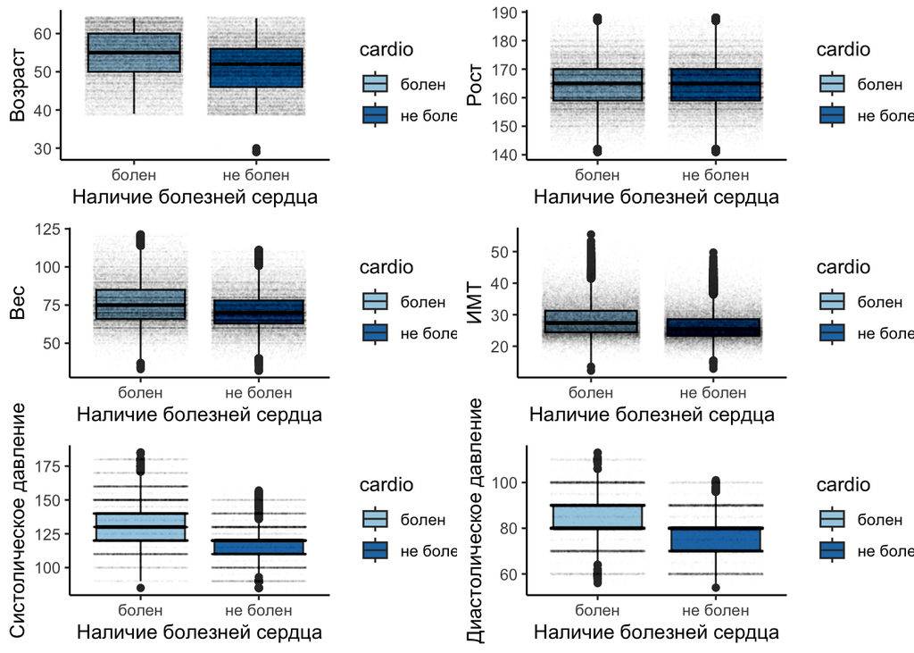

```r
age_boxplot <- cleaned_data %>%
  group_by(cardio) %>%
  ggplot()+
  geom_boxplot(aes(x = cardio, y = age, fill = cardio))+
  geom_jitter(aes(x = cardio,, y = age),
              size = 0.01, alpha = 0.01) +
  scale_fill_brewer(palette = "Paired") +
  labs(x = "Наличие болезней сердца", y = "Возраст")+
  theme_classic()

height_boxplot <- cleaned_data %>%
  group_by(cardio) %>%
  ggplot()+
  geom_boxplot(aes(x = cardio, y = height, fill = cardio))+
  geom_jitter(aes(x = cardio,, y = height),
              size = 0.01, alpha = 0.01) +
  scale_fill_brewer(palette = "Paired") +
  labs(x = "Наличие болезней сердца", y = "Рост")+
  theme_classic()

weight_boxplot <- cleaned_data %>%
  group_by(cardio) %>%
  ggplot()+
  geom_boxplot(aes(x = cardio, y = weight, fill = cardio))+
  geom_jitter(aes(x = cardio,, y = weight),
              size = 0.01, alpha = 0.01) +
  scale_fill_brewer(palette = "Paired") +
  labs(x = "Наличие болезней сердца", y = "Вес")+
  theme_classic()

BMI_boxplot <- cleaned_data %>%
  group_by(cardio) %>%
  ggplot()+
  geom_boxplot(aes(x = cardio, y = BMI, fill = cardio))+
  geom_jitter(aes(x = cardio,, y = BMI),
              size = 0.01, alpha = 0.01) +
  scale_fill_brewer(palette = "Paired") +
  labs(x = "Наличие болезней сердца", y = "ИМТ")+
  theme_classic()

sisBP_boxplot <- cleaned_data %>%
  group_by(cardio) %>%
  ggplot()+
  geom_boxplot(aes(x = cardio, y = sisBP, fill = cardio))+
  geom_jitter(aes(x = cardio,, y = sisBP),
              size = 0.01, alpha = 0.01) +
  scale_fill_brewer(palette = "Paired") +
  labs(x = "Наличие болезней сердца", y = "Систолическое давление")+
  theme_classic()

diaBP_boxplot <- cleaned_data %>%
  group_by(cardio) %>%
  ggplot()+
  geom_boxplot(aes(x = cardio, y = diaBP, fill = cardio))+
  geom_jitter(aes(x = cardio,, y = diaBP),
              size = 0.01, alpha = 0.01) +
  scale_fill_brewer(palette = "Paired") +
  labs(x = "Наличие болезней сердца", y = "Диастолическое давление")+
  theme_classic()

ggarrange(plotlist = list(age_boxplot, height_boxplot, weight_boxplot, BMI_boxplot, sisBP_boxplot, diaBP_boxplot),
          ncol = 2,
          nrow = 3)
```

Без джиттеров смотрелось бы лучше, но как есть, таково задание))

## Категориальные переменные

1. Сделайте подходящие визуализации категориальных переменных. Обоснуйте, почему выбрали именно этот тип.

```r
#Скопировала и сохранила сводную табличку по категориальным метрикам
cat_data <- cleaned_data %>%
  select(cardio, where(is.factor)) %>%
  pivot_longer(-cardio, names_to = "variable", values_to = "value") %>%
  group_by(cardio, variable, value) %>%
  summarise(
    count = n(),
    .groups = "drop_last"
  ) %>%
  group_by(cardio, variable) %>%
  mutate(
    total = sum(count),  # Общее количество в группе для переменной
    percent = count / total,  # Относительное количество
    se = sqrt((percent * (1 - percent)) / total),
    error_margin = qt(0.975, df = total - 1) * se,
    ci_lower = round((count - error_margin), 2),
    ci_upper = round((count + error_margin), 2),
    ci = paste0(ci_lower, " - ", ci_upper)
  ) %>%
  ungroup() %>%
  select(-total, -se, -error_margin, -ci_upper, -ci_lower) %>% # Удалила ненужные столбики
  mutate(percent = round(percent * 100, 2)) %>%
  group_by(cardio)
cat_data
```

| cardio | variable | value | count | percent | ci |
| --- | --- | --- | --- | --- | --- |
| болен | active | активен | 26922 | 78.98 | 26922 - 26922 |
| болен | active | не активен | 7167 | 21.02 | 7167 - 7167 |
| болен | alco | не употребляет | 32340 | 94.87 | 32340 - 32340 |
| болен | alco | употребляет | 1749 | 5.13 | 1749 - 1749 |
| болен | cholesterol | высокий | 5982 | 17.55 | 5982 - 5982 |
| болен | cholesterol | норма | 22563 | 66.19 | 22562.99 - 22563.01 |
| болен | cholesterol | повышенный | 5544 | 16.26 | 5544 - 5544 |
| болен | gender | Ж | 22112 | 64.87 | 22111.99 - 22112.01 |
| болен | gender | М | 11977 | 35.13 | 11976.99 - 11977.01 |
| болен | gluc | высокий | 3205 | 9.40 | 3205 - 3205 |

[output cut: 18 more lines]

Я считаю, что так как группы не равны по количеству субъектов, надо отображать только относительные значение

Самое главное - чтобы из графиков было четко видно, по каким параметрам есть отличия между группами больных и не больных по cardio, поэтому столбики “болен” и “не болен” должны стоять рядом.

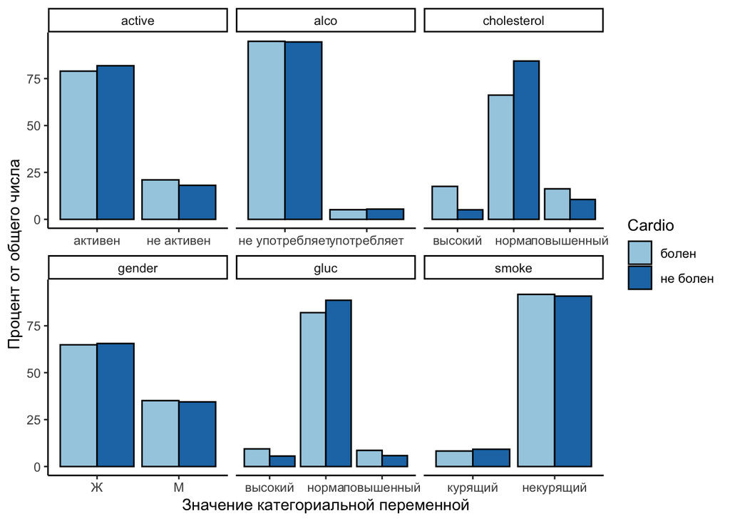

```r
ggplot(cat_data) +
  geom_col(aes(x = value, y = percent, fill = factor(cardio)), color = "black", position = "dodge") + #позиция додж чтобы столбики стояли рядом
  facet_wrap(~variable, scales = "free_x") +
  theme_classic() +
  labs(x = "Значение категориальной переменной", y = "Процент от общего числа", fill = "Cardio") +
  scale_fill_brewer(palette = "Paired")
```

# Статистические оценки

## Проверка на нормальность

1. Оцените каждую переменную на соответствие нормальному распределению с помощью теста Шапиро-Уилка. Какие из переменных являются нормальными и как вы это поняли?

```r
cleaned_data %>%
  group_by(cardio) %>%
  slice(1:5000) %>%
  summarise(across(where(is.numeric),
                   ~ list(shapiro.test(.)),
                   .names = "shapiro_{col}")) %>%
  pivot_longer(-cardio,
               names_to = c(".value", "variable"),
               names_sep = "_") %>%
  mutate(w_shapiro = map_dbl(shapiro, "statistic"),
         p_value = map_dbl(shapiro, "p.value")) %>% #как в одно действие распарсить значение критерия и пи велью я не знаю
  select(-shapiro)%>%
  mutate(p_value = formatC(p_value, format = "e", digits = 3)) %>%
  flextable() %>%
  theme_box() %>%
  align(align="center", part="all") %>%
  width(c("p_value"), width = 2) %>%
  merge_v(c("cardio", "variable"))
```

| cardio | variable | w_shapiro | p_value |
| --- | --- | --- | --- |
| болен | age | 0.8322216 | 2.573e-58 |
|  | height | 0.9953839 | 1.698e-11 |
|  | weight | 0.9815712 | 5.303e-25 |
|  | sisBP | 0.9420365 | 4.594e-40 |
|  | diaBP | 0.8870630 | 8.361e-51 |
|  | BMI | 0.9620311 | 2.642e-34 |
| не болен | age | 0.8970970 | 1.080e-49 |
|  | height | 0.9956668 | 5.192e-11 |
|  | weight | 0.9879861 | 3.197e-20 |
|  | sisBP | 0.8945991 | 6.830e-50 |
|  | diaBP | 0.8375644 | 1.695e-57 |
|  | BMI | 0.9600440 | 5.194e-35 |

Согласно результатам теста Шапиро-Уилка, распределения всех данных значительно отклоняются от нормального. Это и не удивительно, ведь у нас выборки были в 5000 значений, а этот тест работает при малых выборках (до 50)

Я бы все равно использовала параметрические критерии для сравнения значений

2. Постройте для каждой количественной переменной QQ-плот. Отличаются ли выводы от теста Шапиро-Уилка? Какой метод вы бы предпочли и почему?

```r
age_qqplot <-cleaned_data %>%
  group_by(cardio) %>%
  ggplot(aes(sample=age))+
  stat_qq(size = 0.5, alpha = 0.01)+
  stat_qq_line(color = "blue", linetype = "dashed") +
  scale_fill_brewer(palette = "Paired") +
  labs(x = "Теоретические квантили", y = "Наблюдаемые квантили")+
  ggtitle("QQ-график распределения возраста") +
  facet_wrap(~cardio) +
  theme_classic()

height_qqplot <-cleaned_data %>%
  group_by(cardio) %>%
  ggplot(aes(sample=height))+
  stat_qq(size = 0.5, alpha = 0.01)+
  stat_qq_line(color = "blue", linetype = "dashed") +
  scale_fill_brewer(palette = "Paired") +
  labs(x = "Теоретические квантили", y = "Наблюдаемые квантили")+
  ggtitle("QQ-график распределения роста") +
  facet_wrap(~cardio) +
  theme_classic()

weight_qqplot <-cleaned_data %>%
  group_by(cardio) %>%
  ggplot(aes(sample=weight))+
  stat_qq(size = 0.5, alpha = 0.01)+
  stat_qq_line(color = "blue", linetype = "dashed") +
  scale_fill_brewer(palette = "Paired") +
  labs(x = "Теоретические квантили", y = "Наблюдаемые квантили")+
  ggtitle("QQ-график распределения веса") +
  facet_wrap(~cardio) +
  theme_classic()

BMI_qqplot <-cleaned_data %>%
  group_by(cardio) %>%
  ggplot(aes(sample=BMI))+
  stat_qq(size = 0.5, alpha = 0.01)+
  stat_qq_line(color = "blue", linetype = "dashed") +
  scale_fill_brewer(palette = "Paired") +
  labs(x = "Теоретические квантили", y = "Наблюдаемые квантили")+
  ggtitle("QQ-график распределения ИМТ") +
  facet_wrap(~cardio) +
  theme_classic()

sisBP_qqplot <-cleaned_data %>%
  group_by(cardio) %>%
  ggplot(aes(sample=sisBP))+
  stat_qq(size = 0.5, alpha = 0.01)+
  stat_qq_line(color = "blue", linetype = "dashed") +
  scale_fill_brewer(palette = "Paired") +
  labs(x = "Теоретические квантили", y = "Наблюдаемые квантили")+
  ggtitle("QQ систолического АД") +
  facet_wrap(~cardio) +
  theme_classic()

diaBP_qqplot <-cleaned_data %>%
  group_by(cardio) %>%
  ggplot(aes(sample=diaBP))+
  stat_qq(size = 0.5, alpha = 0.01)+
  stat_qq_line(color = "blue", linetype = "dashed") +
  scale_fill_brewer(palette = "Paired") +
  labs(x = "Теоретические квантили", y = "Наблюдаемые квантили")+
  ggtitle("QQ диастолического АД") +
  facet_wrap(~cardio) +
  theme_classic()
```

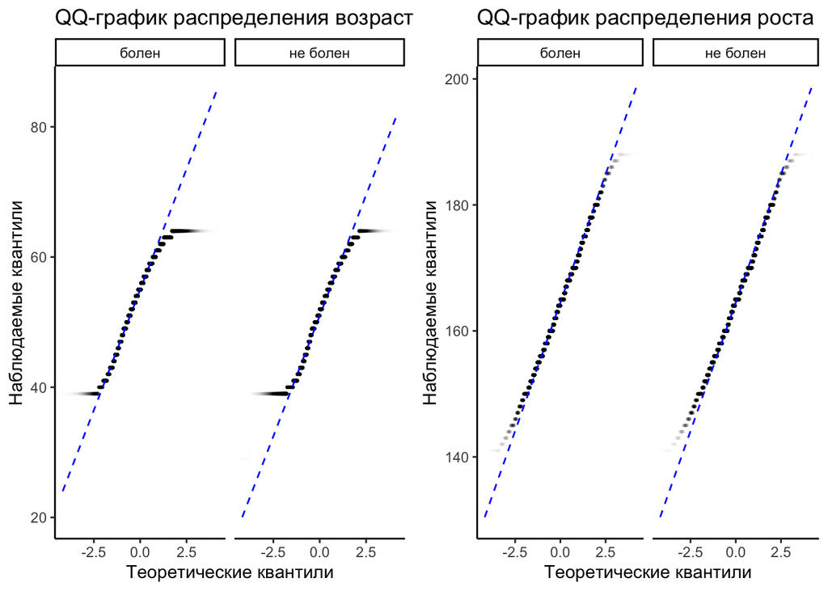

```r
ggarrange(plotlist = list(age_qqplot, height_qqplot),
          ncol = 2,
          nrow = 1,
          heights = c(10),
          widths = c(10, 10) )
```

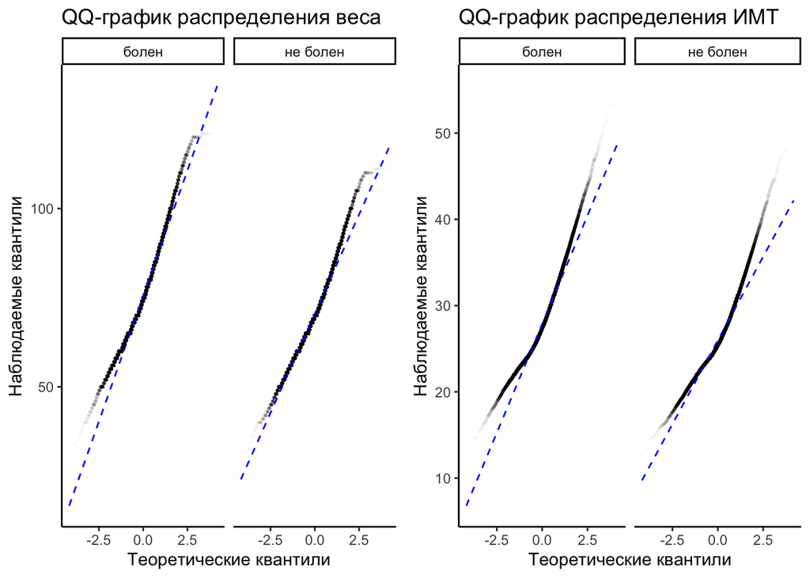

```r
ggarrange(plotlist = list(weight_qqplot, BMI_qqplot),
          ncol = 2,
          nrow = 1,
          heights = c(10),
          widths = c(10, 10) )
```

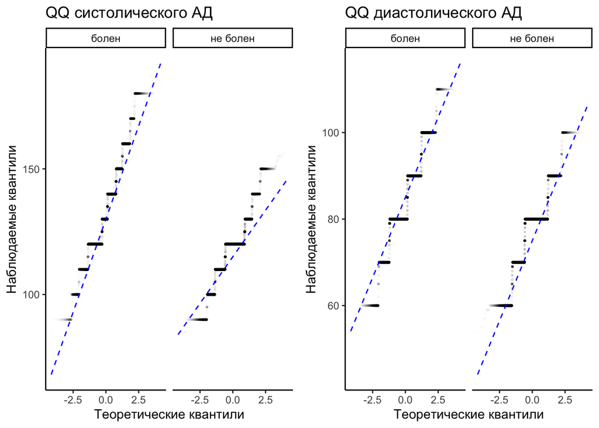

```r
ggarrange(plotlist = list(sisBP_qqplot, diaBP_qqplot),
          ncol = 2,
          nrow = 1,
          heights = c(10),
          widths = c(10, 10) )
```

Интерпретация графиков немного затрудняется тем, что на такой большой выборке непрерывные данные выглядят как дискретные

Рост, вес и давления распределены очень близко к нормальному

ИМТ и возраст не совсем, возраст отклонется в сторону похожести на равномерное распределение, а ИМТ - экспоненциальное, но в пределах нормы

Как и ожидалось, результат не совпал с результатом теста Шапиро-Уилка

*Мы все равно можем считать эти переменные близкими к нормальным согласно центральной предельной теореме*

3. Ниже напишите, какие ещё методы проверки на нормальность вы знаете и какие у них есть ограничения.

**Напишите текст здесь** 1. Колмогорова-Смирнова Чувствителен на больших выборках и может давать ложные срабатывания для малых выборок. Требует, чтобы данные были независимыми и одинаково распределенными 2. Андерсона-Дарлинга Расширение теста Колмогорова-Смирнова, которое уделяет больше внимания хвостам распределения. Может быть менее эффективным для больших выборок. Требует, чтобы данные были независимыми и одинаково распределенными 3. “Посмотреть глазами на гистограмму” Может быть очень субъективным и предвзятым, результат зависит от “религии” исследователя - какие ему тесты больше нравятся, параметрические или непараметрические

## Сравнение групп

1. Сравните группы (переменная **cardio**) по каждой переменной (как количественной, так и категориальной). Для каждой переменной выберите нужный критерий и кратко обоснуйте его выбор в комментариях.

Мы считаем, что все наши количественные переменные распределены нормально, поэтому применяем T-test для них. Для категориальных переменных мы применяем хи-квадрат, так как у нас больше 5 значений в каждой из ячеек таблицы сопряженности

```r
# Количественные переменные и t-тест
quant_vars <- c("age", "height", "weight", "BMI", "sisBP", "diaBP")
t_tests <- map(quant_vars, ~ t.test(as.formula(paste(.x, "~ cardio")), data = cleaned_data) %>%
                 tidy() %>%
                 mutate(variable = .x))

# Категориальные переменные и хи квадрат тест
cat_vars <- c("gender", "cholesterol", "gluc", "smoke", "alco", "active")
chisq_tests <- map(cat_vars, ~ chisq.test(table(cleaned_data[[.x]], cleaned_data$cardio)) %>%
                    tidy() %>%
                    mutate(variable = .x))
results_combined <- bind_rows(t_tests, chisq_tests)
# этот код от чат гпт - я свой тоже написала, но попросила чат его сократить и сделать красивее

# Выводим таблицу
results_combined %>%
  select(variable, statistic, p.value, method) %>% # Удалили ненужные столбики, поменяли порядок в нужных
  mutate(p.value = formatC(p.value, format = "e", digits = 3),
         significance = ifelse(as.numeric(p.value) < 0.05, "yes", "no")) %>%
  flextable() %>%
  theme_box() %>%
  align(align="center", part="all") %>%
  width(c("method", "p.value"), width = 2)
```

| variable | statistic | p.value | method | significance |
| --- | --- | --- | --- | --- |
| age | 65.869151 | 0.000e+00 | Welch Two Sample t-test | yes |
| height | -3.948843 | 7.861e-05 | Welch Two Sample t-test | yes |
| weight | 52.496419 | 0.000e+00 | Welch Two Sample t-test | yes |
| BMI | 55.878362 | 0.000e+00 | Welch Two Sample t-test | yes |
| sisBP | 136.078276 | 0.000e+00 | Welch Two Sample t-test | yes |
| diaBP | 100.222133 | 0.000e+00 | Welch Two Sample t-test | yes |
| gender | 3.561042 | 5.915e-02 | Pearson's Chi-squared test with Yates' continuity correction | no |
| cholesterol | 3,484.348200 | 0.000e+00 | Pearson's Chi-squared test | yes |
| gluc | 601.902124 | 1.989e-131 | Pearson's Chi-squared test | yes |
| smoke | 18.743923 | 1.495e-05 | Pearson's Chi-squared test with Yates' continuity correction | yes |
| alco | 3.660326 | 5.572e-02 | Pearson's Chi-squared test with Yates' continuity correction | no |
| active | 89.871273 | 2.542e-21 | Pearson's Chi-squared test with Yates' continuity correction | yes |

Получается, между группами достоверно различаются следующие параметры: Возраст, рост, вес, ИМТ, давление, уровень холестерина, глюкозы, курение и уровень активности

# Далее идут **необязательные** дополнительные задания, которые могут принести вам дополнительные баллы в том числе в случае ошибок в предыдущих

## Корреляционный анализ

1. Создайте корреляционную матрицу с визуализацией и поправкой на множественные сравнения. Объясните, когда лучше использовать корреляционные матрицы и в чём минусы и плюсы корреляционных исследований.

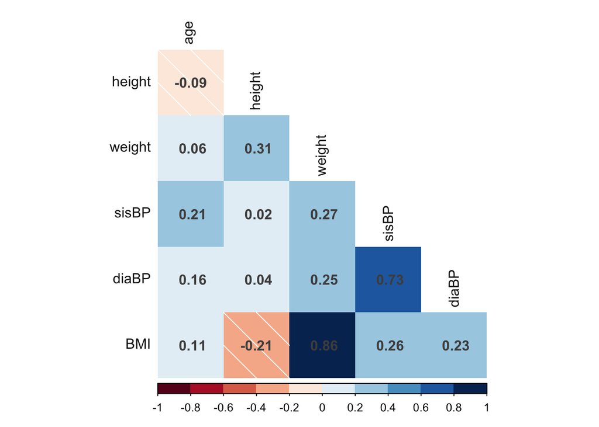

```r
cor_matrix <- cleaned_data %>% #сначала считаем матрицу корреляций
  mutate(age = as.numeric(age))%>%
  select(where(is.numeric), -id) %>%
  drop_na() %>%
  cor(use = "pairwise.complete.obs")

corrplot(cor_matrix, method = "shade", type = "lower", # потом строим плот
         addCoef.col = "grey30", diag = FALSE,         # и нааа маленьком плотууу
         cl.pos = "b", tl.col = "grey10",
         col = COL2('RdBu', 10))
```

Удивительно (нет), но так как ИМТ высчитан из массы тела, он сильно с ней коррелирует

Также неудивительно, что систолическое давление коррелирует с диастолическим

Никаких открытий тут нет, все довольно прозаично…

Оставим отображение только тех корреляций у кого скорректированное пи велью меньше 0,05

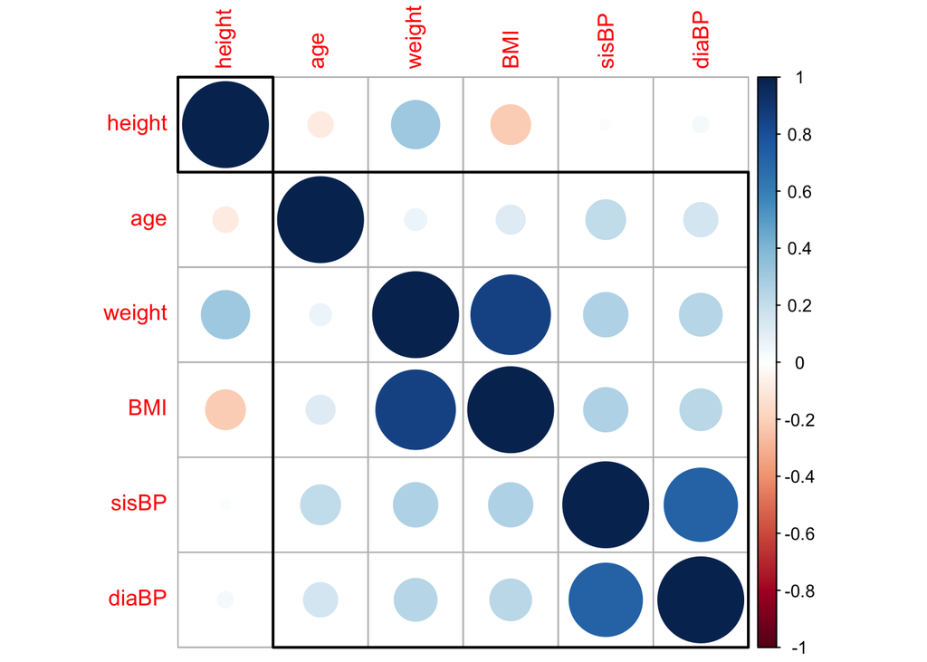

```r
corr_data <- cleaned_data %>% #делаем датасет только из количественных переменных
  mutate(age = as.numeric(age)) %>%
  select(where(is.numeric), -id) %>%
  drop_na()

corr_p = cor.mtest(corr_data, conf.level = 0.95)

p_values <- corr_p$p[!is.na(corr_p$p)]
p_adjusted <- p.adjust(p_values, method = "bonferroni")
corr_p$p[!is.na(corr_p$p)] <- p_adjusted

## specialized the insignificant value according to the 5% significant level
corrplot(cor_matrix, p.mat = corr_p$p, sig.level = 0.05, order = 'hclust', addrect = 2)
```

А у них у всех пи велью меньше 0,05

## Моделирование

1. Постройте регрессионную модель для переменной **cardio**. Опишите процесс построения

```r
#я не умею...
```